# CreditCardChurners

### Attrition_Flag - Total_Trans_Count

```r
summary(BankChurners$Total_Trans_Ct)
```

```
##    Min. 1st Qu.  Median    Mean 3rd Qu.    Max.
##   10.00   45.00   67.00   64.86   81.00  139.00
```

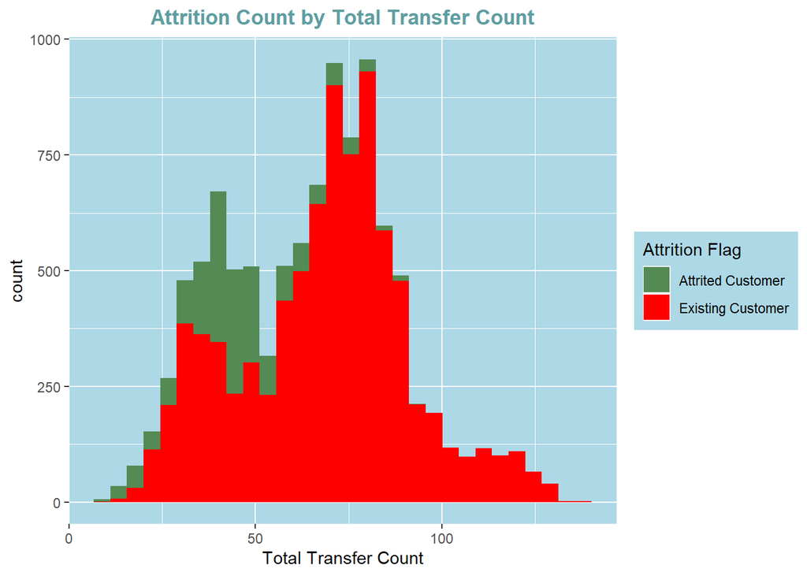

```r
ggplot(data = BankChurners,aes(x=Total_Trans_Ct,fill=Attrition_Flag))+geom_histogram(position = "stack",bins = 30)+labs(title = "Attrition Count by Total Transfer Count",x="Total Transfer Count",fill="Attrition Flag")+theme(panel.background = element_rect(fill = "lightblue"))+theme(plot.title = element_text(hjust = 0.5,face = "bold",colour = "cadetblue"))+scale_fill_manual(values=c("palegreen4","red"))+theme(legend.background = element_rect(fill = "lightblue"))
```

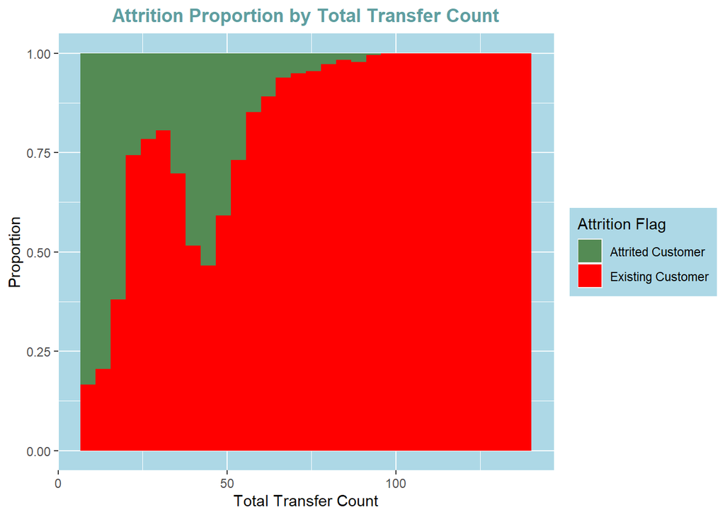

```r
ggplot(data = BankChurners,aes(x=Total_Trans_Ct,fill=Attrition_Flag))+geom_histogram(position = "fill",bins = 30)+labs(title = "Attrition Proportion by Total Transfer Count",x="Total Transfer Count",fill="Attrition Flag")+theme(panel.background = element_rect(fill = "lightblue"))+theme(plot.title = element_text(hjust = 0.5,face = "bold",colour = "cadetblue"))+scale_fill_manual(values=c("palegreen4","red"))+theme(legend.background = element_rect(fill = "lightblue"))+scale_y_continuous("Proportion")
```

1. From the above graphs we get that a major chunk of the customer have Total Transfer count from 50 to 100.
2. Also we get that we have higher rate of attrition when the Total Transfer Count is les than 50.
3. From the proportionate graph above we observe that as the Total Transfer Count increases, the attrition rate decreases.
4. But one unusual pattern we observe that from 25 Total Transfer Count to 50 Total Transfer Count, again the attrition rate increases.
5. Overall the area of concern for the bank should be from 0 Total Transfer Count to 50 Total Transfer Count.

### Attrition_Flag - Total_Count_Change_Q4_Q1

```r
summary(BankChurners$Total_Ct_Chng_Q4_Q1)
```

```
##    Min. 1st Qu.  Median    Mean 3rd Qu.    Max.
##  0.0000  0.5820  0.7020  0.7122  0.8180  3.7140
```

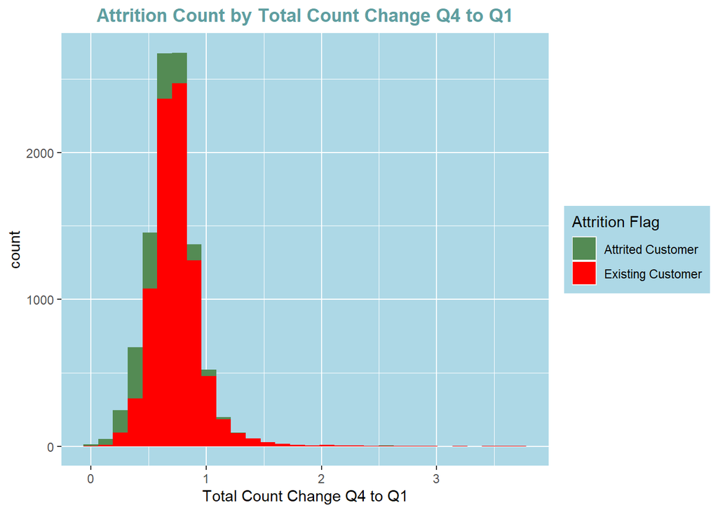

```r
ggplot(data = BankChurners,aes(x=Total_Ct_Chng_Q4_Q1,fill=Attrition_Flag))+geom_histogram(position = "stack",bins = 30)+labs(title = "Attrition Count by Total Count Change Q4 to Q1",x="Total Count Change Q4 to Q1",fill="Attrition Flag")+theme(panel.background = element_rect(fill = "lightblue"))+theme(plot.title = element_text(hjust = 0.5,face = "bold",colour = "cadetblue"))+scale_fill_manual(values=c("palegreen4","red"))+theme(legend.background = element_rect(fill = "lightblue"))
```

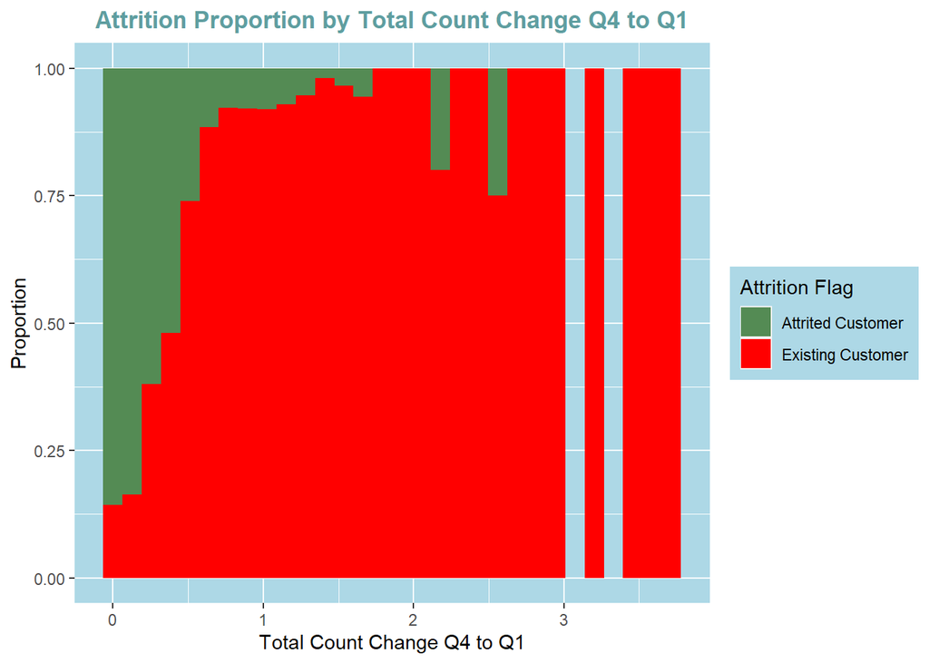

```r
ggplot(data = BankChurners,aes(x=Total_Ct_Chng_Q4_Q1,fill=Attrition_Flag))+geom_histogram(position = "fill",bins = 30)+labs(title = "Attrition Proportion by Total Count Change Q4 to Q1",x="Total Count Change Q4 to Q1",fill="Attrition Flag")+theme(panel.background = element_rect(fill = "lightblue"))+theme(plot.title = element_text(hjust = 0.5,face = "bold",colour = "cadetblue"))+scale_fill_manual(values=c("palegreen4","red"))+theme(legend.background = element_rect(fill = "lightblue"))+scale_y_continuous("Proportion")
```

### Attrition_Flag - Average_Utilization_Ratio

```r
summary(BankChurners$Avg_Utilization_Ratio)
```

```
##    Min. 1st Qu.  Median    Mean 3rd Qu.    Max.
##  0.0000  0.0230  0.1760  0.2749  0.5030  0.9990
```

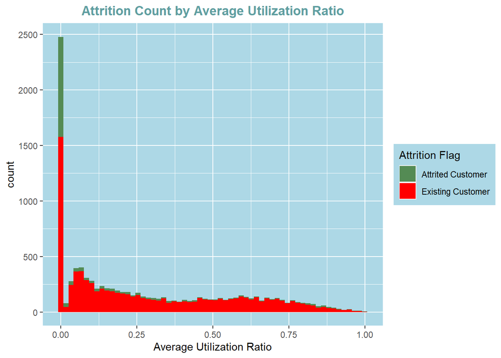

```r
ggplot(data = BankChurners,aes(x=Avg_Utilization_Ratio,fill=Attrition_Flag))+geom_histogram(position = "stack",bins = 60)+labs(title = "Attrition Count by Average Utilization Ratio",x="Average Utilization Ratio",fill="Attrition Flag")+theme(panel.background = element_rect(fill = "lightblue"))+theme(plot.title = element_text(hjust = 0.5,face = "bold",colour = "cadetblue"))+scale_fill_manual(values=c("palegreen4","red"))+theme(legend.background = element_rect(fill = "lightblue"))
```

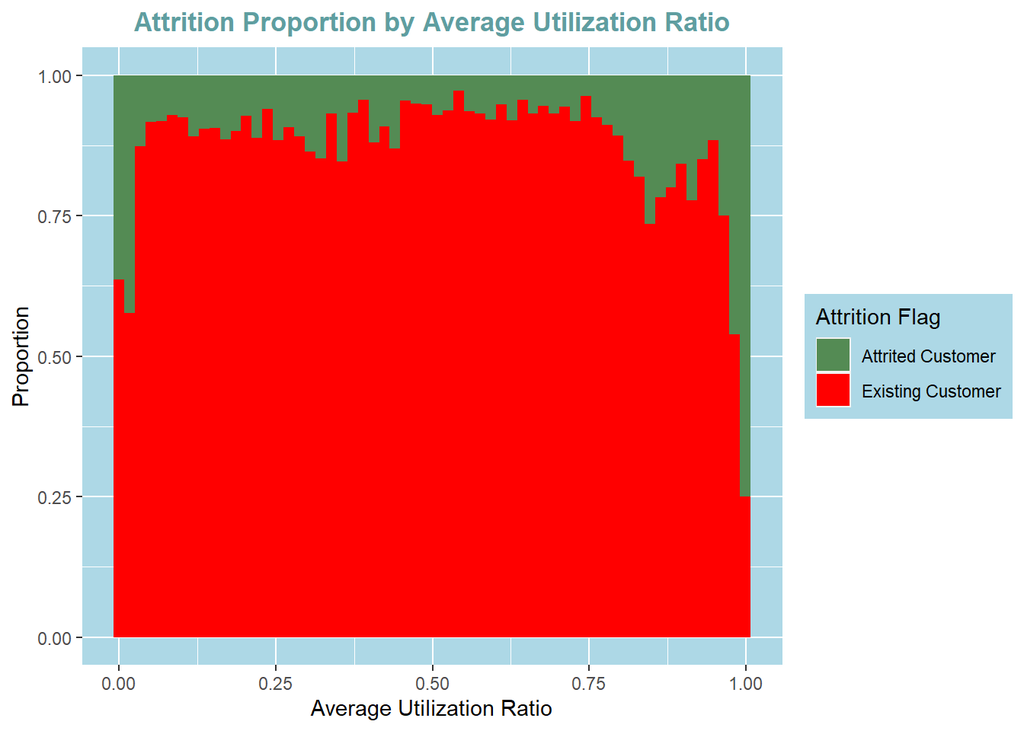

```r
ggplot(data = BankChurners,aes(x=Avg_Utilization_Ratio,fill=Attrition_Flag))+geom_histogram(position = "fill",bins = 60)+labs(title = "Attrition Proportion by Average Utilization Ratio",x="Average Utilization Ratio",fill="Attrition Flag")+theme(panel.background = element_rect(fill = "lightblue"))+theme(plot.title = element_text(hjust = 0.5,face = "bold",colour = "cadetblue"))+scale_fill_manual(values=c("palegreen4","red"))+theme(legend.background = element_rect(fill = "lightblue"))+scale_y_continuous("Proportion")
```

## **Exploring Multivariate Relationships**

### Visualizing various continuous variables with Customer Age coloured by Attrition Flag

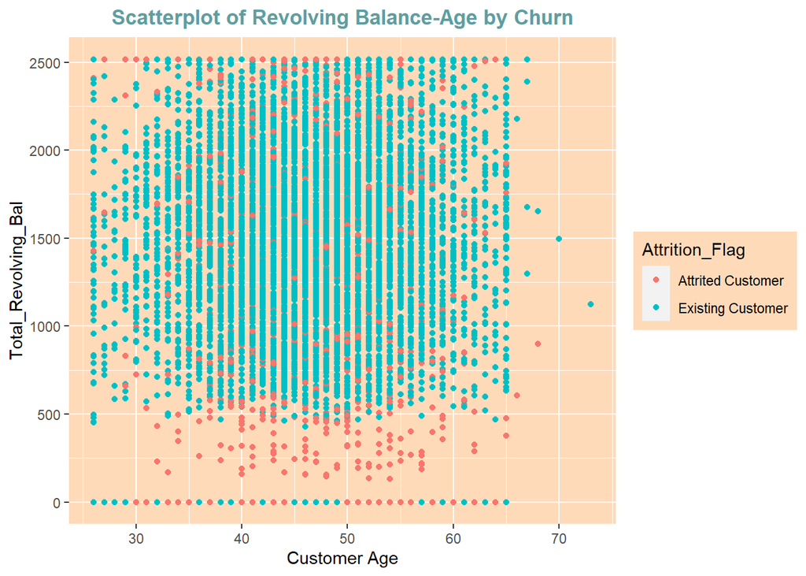

```r
ggplot(data = BankChurners,aes(y=Total_Revolving_Bal,x=Customer_Age,col=Attrition_Flag))+geom_point()+labs(title = "Scatterplot of Revolving Balance-Age by Churn",x="Customer Age",fill="Attrition Flag")+theme(panel.background = element_rect(fill = "peachpuff"))+theme(plot.title = element_text(hjust = 0.5,face = "bold",colour = "cadetblue"))+theme(legend.background = element_rect(fill = "peachpuff"))
```

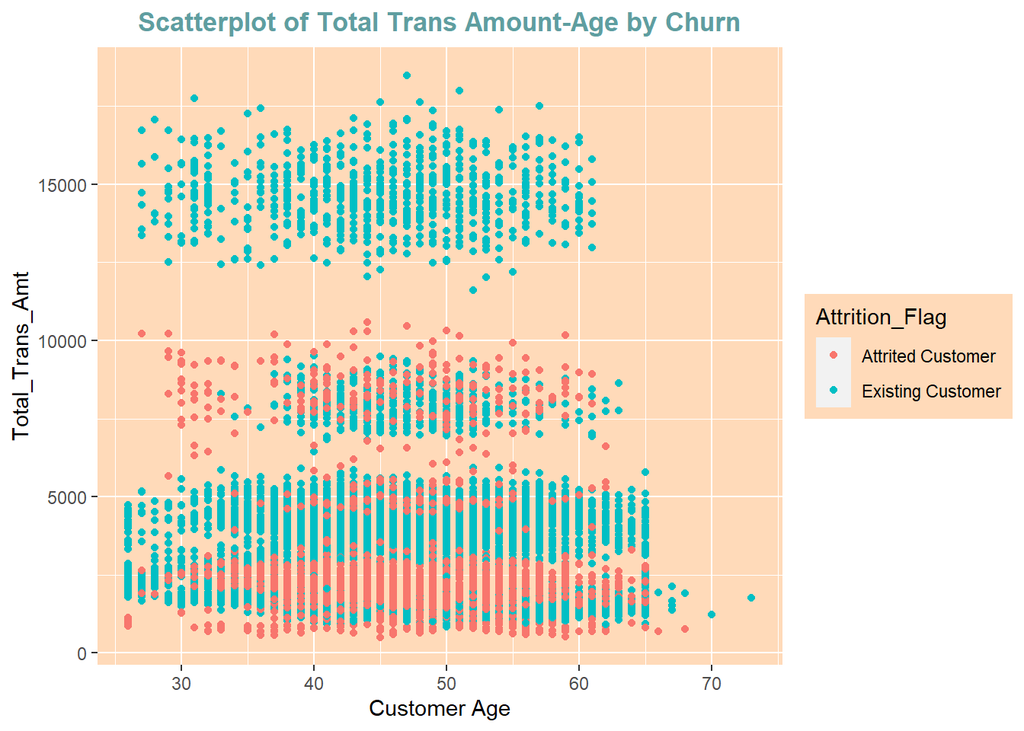

```r
ggplot(data = BankChurners,aes(y=Total_Trans_Amt,x=Customer_Age,col=Attrition_Flag))+geom_point()+labs(title = "Scatterplot of Total Trans Amount-Age by Churn",x="Customer Age",fill="Attrition Flag")+theme(panel.background = element_rect(fill = "peachpuff"))+theme(plot.title = element_text(hjust = 0.5,face = "bold",colour = "cadetblue"))+theme(legend.background = element_rect(fill = "peachpuff"))
```

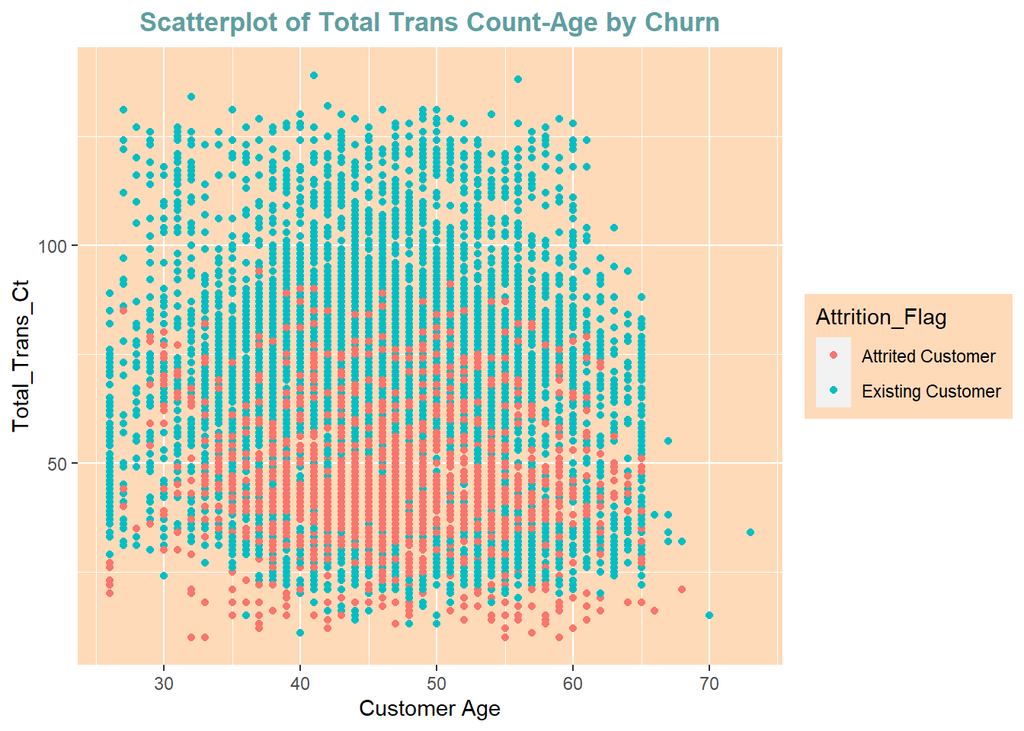

```r
ggplot(data = BankChurners,aes(y=Total_Trans_Ct,x=Customer_Age,col=Attrition_Flag))+geom_point()+labs(title = "Scatterplot of Total Trans Count-Age by Churn",x="Customer Age",fill="Attrition Flag")+theme(panel.background = element_rect(fill = "peachpuff"))+theme(plot.title = element_text(hjust = 0.5,face = "bold",colour = "cadetblue"))+theme(legend.background = element_rect(fill = "peachpuff"))
```

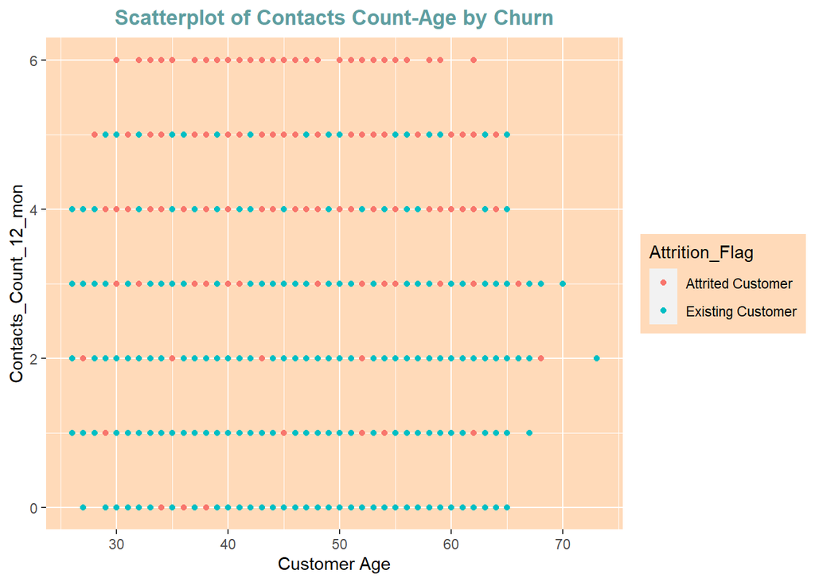

```r
ggplot(data = BankChurners,aes(y=Contacts_Count_12_mon,x=Customer_Age,col=Attrition_Flag))+geom_point()+labs(title = "Scatterplot of Contacts Count-Age by Churn",x="Customer Age",fill="Attrition Flag")+theme(panel.background = element_rect(fill = "peachpuff"))+theme(plot.title = element_text(hjust = 0.5,face = "bold",colour = "cadetblue"))+theme(legend.background = element_rect(fill = "peachpuff"))
```

1. From the first graph we observe that customers of all age are more attrited customers who have total revolving balance less than 500.
2. From the second graph we see that customers of all age have more attrition rate when there total transfer amount is less than 3000. Also as the Total Transfer Amount from 750 to 1000, customers have higher attrition rate. The customers with more than 12500 Total Transfer Amount has no attrition at all.
3. From the third figure above we observe that the area between Total Transfer Count of 25-75 and between 30-60 age group, the customers tend to churn the credit card service more which is the area of concern.
4. From the fourth graph above, we observe that as the number of contact counts reaches 4 and beyond, the attrition rate increases in the customers of all age group.